# statar

Matthieu Gomez

2014-10-30

# String and expression interpolation

- The functions `pastem` corresponds to string interpolations similarly to Stata and Julia.

`R name <- "Bob" height <- 72 units <- "inches" weight <- 230 pastem("My record indicates your height is $height $(units).") #> [1] "My record indicates your height is 72 inches" pastem("Your body mass index is $(round(703*weight/height^2,1))") #> [1] "Your body mass index is 31.2" a <- "ght" pastem("My record indicates you are $(hei$a) inches tall") #> [1] "My record indicates you are 72 inches tall"` The option pattern allows to use a different pattern. `R pastem("My record indicates you are #height inches tall", pattern = "#") #> [1] "My record indicates you are 72 inches tall"`

If you choose a common pattern, the option `parenthesis.only = TRUE` allows to replace only expressions enclosed in parenthesis. Note that only the first dot is replaced in the following string:

`R pastem("You are .(height) inches tall.This is below average", pattern = ".", parenthesis.only = TRUE) #> [1] "You are 72 inches tall.This is below average."`

- The function `quotem` implements expression interpolations. The function `evalm` is a wrapper for `eval(quotem())`: it corresponds to Julia `@eval` and to Stata natural macros (although restricted to name substitutions).

`` R library(statar) library(data.table) N <- 100 DT <- data.table( id = sample(5, N, TRUE), v1 = sample(5, N, TRUE), v2 = sample(1e6, N, TRUE) ) newvar <- quote(temp) myvar <- quote(v1) byvar <- c("id", "v1") quotem(DT[, list(`$newvar` = mean(`$myvar`)), by = `$byvar`]) #> DT[, list(temp = mean(v1)), by = c("id", "v1")] evalm(DT[, list(`$newvar` = mean(`$myvar`)), by = `$byvar`]) #> id v1 temp #> 1: 2 4 4 #> 2: 5 5 5 #> 3: 4 5 5 #> 4: 1 3 3 #> 5: 5 2 2 #> 6: 3 4 4 #> 7: 3 5 5 #> 8: 3 1 1 ``

Note that names starting with the pattern `$` must be enclosed in backquotes to be considered valid names in R.

# Vector functions

The package adds the following vector functions

```r
# sample_mode returns the statistical mode
sample_mode(c(1, 2, 2))
sample_mode(c(1, 2))
sample_mode(c(NA, NA, 1))
sample_mode(c(NA, NA, 1), na.rm = TRUE)

# bin creates integer variable for quantile categories (corresponds to Stata xtile)
v <- c(NA, 1:10)
bin(v, n_quantiles = 3) # 3 groups based on terciles
bin(v, probs = c(0.3, 0.7)) # 3 groups based on two quantiles
bin(v, cutpoints = c(2, 3)) # 3 groups based on two cutpoints

# winsorize (default based on 5 x interquartile range)
v <- c(1:4, 99)
winsorize(v)
winsorize(v, replace = NA)
winsorize(v, probs = c(0.01, 0.99))
winsorize(v, cutpoints = c(1, 50))

# demean on multiple groups (ie multiple fixed effects)
demean(c(1,2), fe = c(1,1))
demean(c(NA,2), fe = list(c(1,2), c(1,3)))
demean(c(1,2), fe = list(c(NA,2), c(1,3)))
```

# data.table functions

## Summary

```r
# setkeep keeps certain columns inplace
DT <- data.table(
  id = c(1,2),
  v1 = c(1,1),
  v2 = c(2,1)
)
setkeep(DT, list(id, v2))
setkeep(DT, -id)

# sum_up prints detailed summary statistics (corresponds to Stata summarize)
N <- 100
DT <- data.table(
  id = 1:N,
  v1 = sample(5, N, TRUE),
  v2 = sample(1e6, N, TRUE)
)
sum_up(DT)
sum_up(DT, v2, d = TRUE)
sum_up(DT, starts_with("v"), by = v1)

# tab returns cross tabulation table (faster than tabulate)
tab(DT, id)
tab(DT, id, v1, w = v2)

# duplicates returns duplicated rows
DT <- data.table(a = rep(1:2, each = 3), b = 1:6)
duplicates(DT, by = a)
duplicates(DT, by = list(a,b))
```

## Join

`join` is a wrapper for data.table merge functionalities.

- The option “kind” specifies the kind of join based on SQL syntax. Possible kinds are : left, right, inner, outer, semi, anti and cross.

| Stata | statar |
| --- | --- |
| merge v1 | join(x, y, kind = “outer”) |
| merge v1, keep(master matched) | join(x, y, kind = “left”) |
| merge v1, keep(matched using) | join(x, y, kind = “right”) |
| merge v1, keep(matched) | join(x, y, kind = “inner”) |
| merge v1, keep(matched) keepusing(v1) | join(x, y, kind = “semi”) |
| merge v1, keep(master) keepusing(v1) | join(x, y, kind = “anti”) |
| crossby | join(x, y, kind = “cross”) |

- The option “check” checks there are no duplicates in the master or using data.tables (as in Stata).

`r # merge m:1 v1 join(x, y, kind = "outer", check = m~1)` - The option “gen” specifies the name of a new variable that identifies non matched and matched rows (as in Stata).

`r # merge m:1 v1, gen(_merge) join(x, y, kind = "outer", gen = "_merge")`

- The option “inplace” specifies whether the dataset x should be merged in place. It is only available for left joins, when y has no duplicates (for now).

## Panel data

The classes “weekly”, “monthly”, “quarterly” print as dates and are compatible with usual time extraction (ie `month`, `year`, etc). Yet, they are stored as integers representing the number of elapsed periods since 1970/01/0 (resp in week, months, quarters). This is particularly handy for simple algebra:

```r
 # elapsed dates
 library(lubridate)
 date <- mdy(c("04/03/1992", "01/04/1992", "03/15/1992"))
 datem <- as.monthly(date)
 # displays as a period
 datem
 #> [1] "1992m04" "1992m01" "1992m03"
 # behaves as an integer for numerical operations:
 datem + 1
 #> [1] "1992m05" "1992m02" "1992m04"
 # behaves as a date for period extractions:
 year(datem)
 #> [1] 1992 1992 1992
```

Lag/lead create lag/lead variables (corresponds to Stata L. F.).

```r
year <- c(1989, 1911, 1992)
value <- c(4.1, 4.5, 3.3)
lag(value, 1, order_by = year) # returns value in previous year, like  dplyr::lag
lag(value, 1, along_with = year) #  returns value in year - 1
library(lubridate)
date <- mdy(c("04/03/1992", "01/04/1992", "03/15/1992"))
datem <- as.monthly(date)
value <- c(4.1, 4.5, 3.3, 5.3)
lag(value, along_with = datem)
```

roll applies a function along a time variable

```r
year <- c(1989, 1991, 1992)
value <- c(1, 1, 1)
roll(value, sum, n = 2, order_by = year) # based on the two previous rows
roll(value, sum, n = 2, along_with = year) # based on year between [year-2, year]
```

fill_gap fills in gaps in a data.table time variable (corresponds to Stata tsfill)

```r
DT <- data.table(
    id    = c(1, 1, 1, 2, 2),
    year  = c(1992, 1989, 1991, 1992, 1991),
    value = c(4.1, 4.5, 3.3, 3.2, 5.2)
)
fill_gap(DT, value, along_with = year, by = id)
library(lubridate)
DT[, date:= mdy(c("03/01/1992", "04/03/1992", "07/15/1992", "08/21/1992", "10/03/1992"))]
DT[, datem :=  as.monthly(date)]
fill_gap(DT, value, along_with = datem, by = id)
```

setna fills in missing values along a time variable

```r
DT <- data.table(
 id    = c(1, 1, 1, 1, 2, 2),
 date  = c(1992, 1989, 1991, 1993, 1992, 1991),
 value = c(NA, NA, 3, NA, 3.2, 5.2)
)
DT1 <- copy(DT)
setkey(DT1, id, date)
DT2 <- copy(DT1)
DT3 <- copy(DT1)
setna(DT, value, along_with = date, by = id)
setna(DT1)
setna(DT2, value, rollends = TRUE)
setna(DT3, value, roll = "nearest")
```

## Visual exploration

`graph` is a wrapper for `ggplot2` functionalities, useful for interactive exploration of datasets

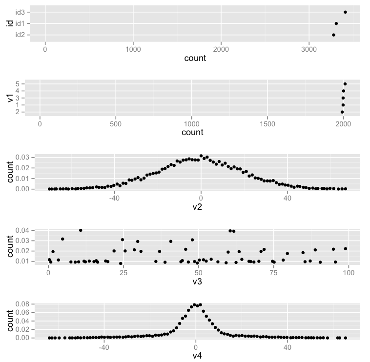

```r
N <- 10000
DT <- data.table(
  id = sample(c("id1","id2","id3"), N, TRUE),
  v1 = sample(c(1:5), N, TRUE),
  v2 = rnorm(N, sd = 20),
  v3 = sample(runif(100, max=100), N, TRUE)
)
DT[, v4 := (id=="id1")* v2 + rnorm(N, sd = 5)]
graph(DT)
```

[figure not shown]

```r
graph(DT, by = id)
```

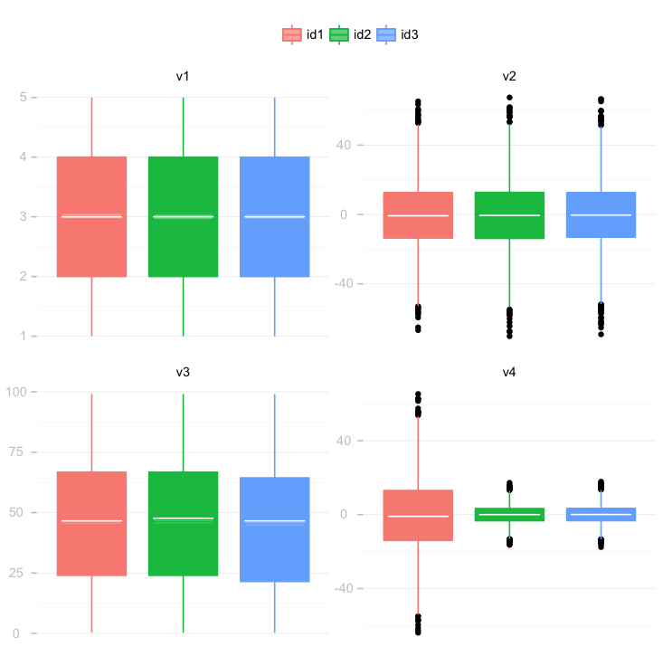

```r
graph(DT, by = id, type = "boxplot")
```

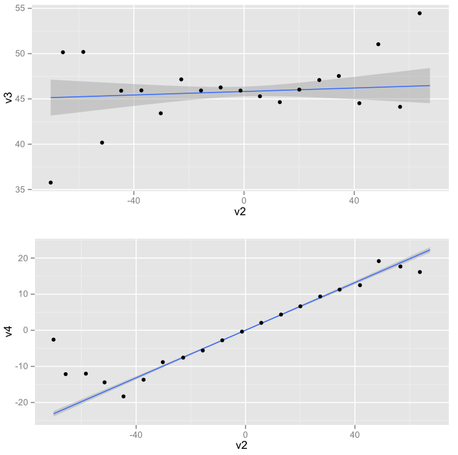

```r
graph(DT, list(v3, v4), along_with = v2)
```

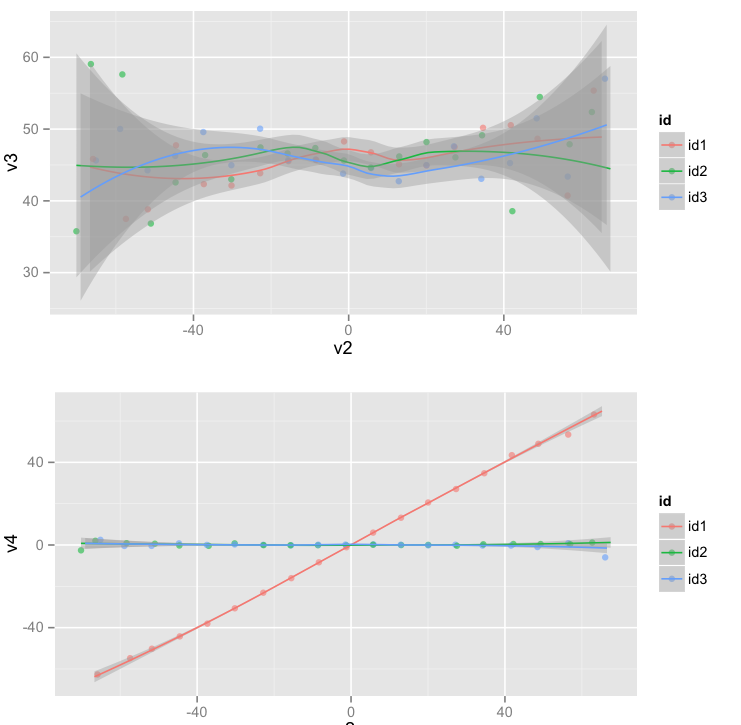

```r
graph(DT, list(v3, v4), along_with = v2, by = id, type = "loess")
```

## Syntax

Functions with the prefix `set` modify the input data.table in place. Function selects variables similarly to `dplyr` syntax. Each function has a version that accepts strings, formulas or quoted expressions : its name is the original function’s name with the suffix _ (see the [dplyr vignette](https://github.com/hadley/dplyr/blob/master/vignettes/nse.Rmd) for more details). For instance, the SE version of `sum_up` is `sum_up_`.

```r
# NSE version
sum_up(DT, list(v2, v3), by = list(id,v1))
# SE version
sum_up_(DT, c("v2","v3"), by = c("id","v1"))
```

# Others

This package also adds

- A data.table method for the generic `tidyr::spread` that relies on `dcast.data.table` (much faster).
- `floor_date`, originally from the package `lubridate`, now accepts “quarter” as an argument
- `tempname` returns a character that corresponds to a name not assigned in the environment (or list, or character vector) specified by the first variable.

```r
tempname(c("temp1", "temp3"), 4)
tempname(globalenv())
temp <- tempname(data.frame(temp = 1))
library(dplyr)
df %>% mutate(`$temp`=mean(temp))
```